# Détection d'anomalies dans les données de consommation énergétique

Ce projet a pour objectif de détecter des anomalies dans les données de consommation énergétique à l'aide d'algorithmes d'apprentissage automatique. Nous utiliserons des modèles tels que **Isolation Forest** et **One-Class SVM** pour la détection d'anomalies. Le but est d'identifier des comportements inhabituels de consommation d'énergie qui pourraient indiquer des inefficacités ou des problèmes potentiels.

```python
# Importation des bibliothèques nécessaires
import pandas as pd
import numpy as np
import matplotlib.pyplot as plt
from sklearn.ensemble import IsolationForest  # Algorithme de détection d'anomalies
from sklearn.svm import OneClassSVM  # Autre algorithme de détection d'anomalies
```

#### Comprendre la problèmatique :

#### Contexte :

##### Dans un contexte où la consommation énergétique augmente, il est crucial pour les entreprises et les collectivités de surveiller leur consommation d'énergie pour détecter des anomalies qui pourraient indiquer des problèmes techniques ou des usages inefficaces. Les anomalies peuvent être dues à des pannes d'équipement, à des comportements inhabituels des consommateurs ou à des variations saisonnières non anticipées.

#### Comment détecter efficacement les anomalies dans les données de consommation énergétique d'une entreprise au fil du temps afin de minimiser les coûts d'exploitation et d'optimiser la consommation d'énergie ?

## Étape 1 : Charger les données

trouver un jeu de donnée sur lequel on va travailler et utiliser Pandas pour le structurer et le nettyoyer

```python
data = pd.read_csv('Energy_consumption.csv')
```

```python
#afficher les 5 premières lignes
data.head()
```

|  | Timestamp | Temperature | Humidity | SquareFootage | Occupancy | HVACUsage | LightingUsage | RenewableEnergy | DayOfWeek | Holiday | EnergyConsumption |
| --- | --- | --- | --- | --- | --- | --- | --- | --- | --- | --- | --- |
| 0 | 2022-01-01 00:00:00 | 25.139433 | 43.431581 | 1565.693999 | 5 | On | Off | 2.774699 | Monday | No | 75.364373 |
| 1 | 2022-01-01 01:00:00 | 27.731651 | 54.225919 | 1411.064918 | 1 | On | On | 21.831384 | Saturday | No | 83.401855 |
| 2 | 2022-01-01 02:00:00 | 28.704277 | 58.907658 | 1755.715009 | 2 | Off | Off | 6.764672 | Sunday | No | 78.270888 |
| 3 | 2022-01-01 03:00:00 | 20.080469 | 50.371637 | 1452.316318 | 1 | Off | On | 8.623447 | Wednesday | No | 56.519850 |
| 4 | 2022-01-01 04:00:00 | 23.097359 | 51.401421 | 1094.130359 | 9 | On | Off | 3.071969 | Friday | No | 70.811732 |

## Étape 2 : Vérifier les données

Nous allons examiner les données pour voir si elles contiennent des valeurs manquantes et vérifier les types de données pour nous assurer qu'elles sont prêtes à être utilisées.

```python
# Pour pouvoir detecter les anomies il va falloir preparer les data et donc il faut verifier s'il y a es valeurs manquantes
data.info()
```

```
<class 'pandas.core.frame.DataFrame'>
RangeIndex: 1000 entries, 0 to 999
Data columns (total 11 columns):
 #   Column             Non-Null Count  Dtype
---  ------             --------------  -----
 0   Timestamp          1000 non-null   object
 1   Temperature        1000 non-null   float64
 2   Humidity           1000 non-null   float64
 3   SquareFootage      1000 non-null   float64
 4   Occupancy          1000 non-null   int64
 5   HVACUsage          1000 non-null   object
 6   LightingUsage      1000 non-null   object
 7   RenewableEnergy    1000 non-null   float64
 8   DayOfWeek          1000 non-null   object
 9   Holiday            1000 non-null   object
 10  EnergyConsumption  1000 non-null   float64
dtypes: float64(5), int64(1), object(5)
memory usage: 86.1+ KB
```

```python
# maintenant on va visualiser les statistiques descriptives. cela donnera une idée sur la distrubtion des données
data.describe()
```

|  | Temperature | Humidity | SquareFootage | Occupancy | RenewableEnergy | EnergyConsumption |
| --- | --- | --- | --- | --- | --- | --- |
| count | 1000.000000 | 1000.000000 | 1000.000000 | 1000.000000 | 1000.000000 | 1000.000000 |
| mean | 24.982026 | 45.395412 | 1500.052488 | 4.581000 | 15.132813 | 77.055873 |
| std | 2.836850 | 8.518905 | 288.418873 | 2.865598 | 8.745917 | 8.144112 |
| min | 20.007565 | 30.015975 | 1000.512661 | 0.000000 | 0.006642 | 53.263278 |
| 25% | 22.645070 | 38.297722 | 1247.108548 | 2.000000 | 7.628385 | 71.544690 |
| 50% | 24.751637 | 45.972116 | 1507.967426 | 5.000000 | 15.072296 | 76.943696 |
| 75% | 27.418174 | 52.420066 | 1740.340165 | 7.000000 | 22.884064 | 82.921742 |
| max | 29.998671 | 59.969085 | 1999.982252 | 9.000000 | 29.965327 | 99.201120 |

```python
#maintenant les probleme dans les jeux de données sont les valeurs manquantes et du coup on foit soit les supprimer ou bien les imputer
data.isnull().sum()
# on peut conclure que on n'a pas des valeurs manquantes
```

```
Timestamp            0
Temperature          0
Humidity             0
SquareFootage        0
Occupancy            0
HVACUsage            0
LightingUsage        0
RenewableEnergy      0
DayOfWeek            0
Holiday              0
EnergyConsumption    0
dtype: int64
```

```python
data_df = pd.DataFrame(data)
```

```python
data
```

|  | Timestamp | Temperature | Humidity | SquareFootage | Occupancy | HVACUsage | LightingUsage | RenewableEnergy | DayOfWeek | Holiday | EnergyConsumption |
| --- | --- | --- | --- | --- | --- | --- | --- | --- | --- | --- | --- |
| 0 | 2022-01-01 00:00:00 | 25.139433 | 43.431581 | 1565.693999 | 5 | On | Off | 2.774699 | Monday | No | 75.364373 |
| 1 | 2022-01-01 01:00:00 | 27.731651 | 54.225919 | 1411.064918 | 1 | On | On | 21.831384 | Saturday | No | 83.401855 |
| 2 | 2022-01-01 02:00:00 | 28.704277 | 58.907658 | 1755.715009 | 2 | Off | Off | 6.764672 | Sunday | No | 78.270888 |
| 3 | 2022-01-01 03:00:00 | 20.080469 | 50.371637 | 1452.316318 | 1 | Off | On | 8.623447 | Wednesday | No | 56.519850 |
| 4 | 2022-01-01 04:00:00 | 23.097359 | 51.401421 | 1094.130359 | 9 | On | Off | 3.071969 | Friday | No | 70.811732 |
| ... | ... | ... | ... | ... | ... | ... | ... | ... | ... | ... | ... |
| 995 | 2022-02-11 11:00:00 | 28.619382 | 48.850160 | 1080.087000 | 5 | Off | Off | 21.194696 | Saturday | No | 82.306692 |
| 996 | 2022-02-11 12:00:00 | 23.836647 | 47.256435 | 1705.235156 | 4 | Off | On | 25.748176 | Tuesday | Yes | 66.577320 |
| 997 | 2022-02-11 13:00:00 | 23.005340 | 48.720501 | 1320.285281 | 6 | Off | On | 0.297079 | Friday | Yes | 72.753471 |
| 998 | 2022-02-11 14:00:00 | 25.138365 | 31.306459 | 1309.079719 | 3 | On | Off | 20.425163 | Thursday | Yes | 76.950389 |
| 999 | 2022-02-11 15:00:00 | 23.051165 | 42.615421 | 1018.140606 | 6 | Off | On | 2.455657 | Saturday | No | 71.545311 |

1000 rows × 11 columns

## Étape 3 : Préparation des données

```python
# maintenant il est tres conseiller de changer TimeStamp en valeur numerique :
data['Timestampime'] = pd.to_datetime(data['Timestamp'])
```

```python
data.set_index('Timestamp', inplace=True)
```

```python
data.info()
```

```
<class 'pandas.core.frame.DataFrame'>
Index: 1000 entries, 2022-01-01 00:00:00 to 2022-02-11 15:00:00
Data columns (total 11 columns):
 #   Column             Non-Null Count  Dtype
---  ------             --------------  -----
 0   Temperature        1000 non-null   float64
 1   Humidity           1000 non-null   float64
 2   SquareFootage      1000 non-null   float64
 3   Occupancy          1000 non-null   int64
 4   HVACUsage          1000 non-null   object
 5   LightingUsage      1000 non-null   object
 6   RenewableEnergy    1000 non-null   float64
 7   DayOfWeek          1000 non-null   object
 8   Holiday            1000 non-null   object
 9   EnergyConsumption  1000 non-null   float64
 10  Timestampime       1000 non-null   datetime64[ns]
dtypes: datetime64[ns](1), float64(5), int64(1), object(4)
memory usage: 93.8+ KB
```

```python
data.dtypes
```

```
Temperature                 float64
Humidity                    float64
SquareFootage               float64
Occupancy                     int64
HVACUsage                    object
LightingUsage                object
RenewableEnergy             float64
DayOfWeek                    object
Holiday                      object
EnergyConsumption           float64
Timestampime         datetime64[ns]
dtype: object
```

## Étape 4 : Visualisation des données

#### Visualisation de la consommation d'énergie

Avant de détecter les anomalies, il est utile de visualiser les données pour comprendre leur tendance et leur comportement général.

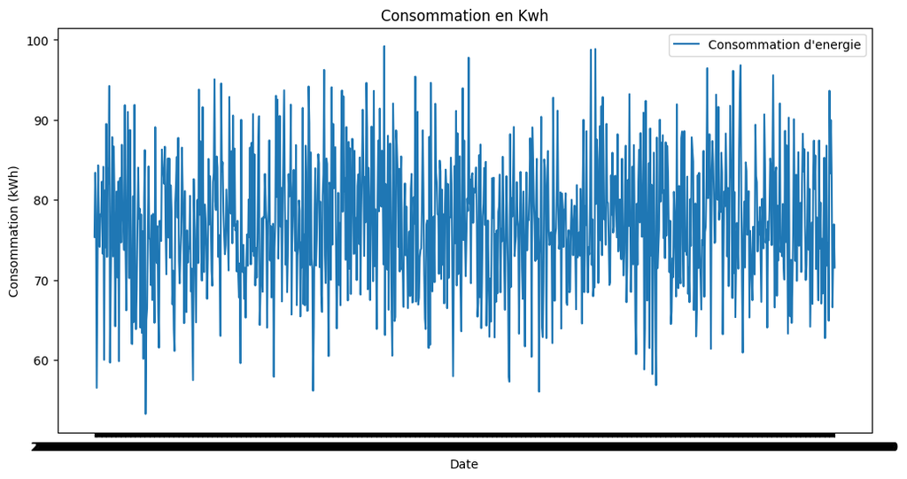

```python
plt.figure(figsize=(12,6))
plt.plot(data.index, data['EnergyConsumption'], label = 'Consommation d\'energie')
plt.title('Consommation en Kwh')
plt.xlabel('Date')
plt.ylabel('Consommation (kWh)')
plt.legend()
```

## Étape 5 : Détection des anomalies avec Isolation Forest

L'algorithme **Isolation Forest** est utilisé pour détecter des points de données qui semblent être des "outliers" par rapport aux autres. Nous allons entraîner ce modèle sur la consommation d'énergie et identifier les points qui semblent anormaux.

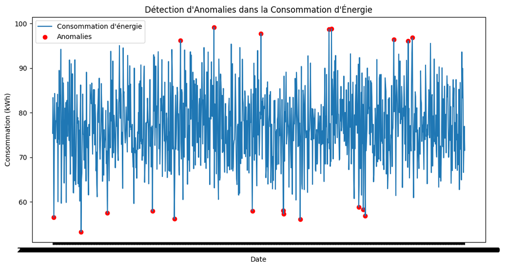

```python
# Créer un modèle Isolation Forest
model = IsolationForest(contamination=0.02)  # Ajustez la contamination selon vos besoins

# Ajuster le modèle
data['Anomaly'] = model.fit_predict(data[['EnergyConsumption']])

# Visualiser les anomalies
plt.figure(figsize=(12, 6))

# Tracer la consommation d'énergie
plt.plot(data.index, data['EnergyConsumption'], label='Consommation d\'énergie')

# Tracer les anomalies
plt.scatter(data.index[data['Anomaly'] == -1], data['EnergyConsumption'][data['Anomaly'] == -1], color='red', label='Anomalies')

# Personnaliser le graphique
plt.title('Détection d\'Anomalies dans la Consommation d\'Énergie')
plt.xlabel('Date')
plt.ylabel('Consommation (kWh)')
plt.legend()
plt.show()
```

## Étape 6 : (Supplémentaire) Détection des anomalies avec One-Class SVM

L'algorithme **One-Class SVM** est une autre méthode de détection d'anomalies. Il fonctionne en apprenant les frontières des données normales et en marquant celles qui tombent en dehors de ces frontières comme anormales.

[figure not shown]

```python
from sklearn.svm import OneClassSVM

# Create OneClassSVM model
svm_model = OneClassSVM(nu=0.05, kernel="rbf", gamma=0.1)

# Fit the model
data['Anomaly_SVM'] = svm_model.fit_predict(data[['EnergyConsumption']])

# Visualize anomalies detected by SVM
plt.figure(figsize=(12, 6))
plt.plot(data.index, data['EnergyConsumption'], label='Energy Consumption')
plt.scatter(data.index[data['Anomaly_SVM'] == -1],
            data['EnergyConsumption'][data['Anomaly_SVM'] == -1],
            color='orange', label='Anomalies by SVM', marker='o')
plt.title('Anomaly Detection using One-Class SVM')
plt.xlabel('Date')
plt.ylabel('Energy Consumption (kWh)')
plt.legend()
plt.grid(True)
plt.show()
```

## Conclusion

Nous avons utilisé deux techniques de détection d'anomalies (Isolation Forest et One-Class SVM) pour identifier des comportements anormaux dans les données de consommation d'énergie. Ces anomalies peuvent être étudiées plus en détail pour détecter des inefficacités ou des défaillances potentielles.